# Classification of titanic data

Vladislav Brion

03 September, 2020

This report contains results of applying various supervised learning methods to titanic data. Quality of survival outcome predictions is outlined.

### The data

The fare variable contains 17 zero records. I consider these values as incorrect, and imputed them using the average fare for corresponding pclass. Also, logarithmic transformation is applied for the fare variable. This transformation will not affect on tree methods, but can improve the logistic regression.

The age variable contains 263 missing records. It is relatively large number, and imputation of these missing values is outside of this report. The following two models can be considered:

1. Model containing the age variable. All records with missing age should be excluded from analysis, and its quality will drop.
2. The age variable is excluded from the model. This model will contain more records. However, the age variable may be important predictor. As a result, omitting this variable would also decrease the quality of analysis.

This report is based on the first model. Two records with missing embarkedvalues will be removed later.

For applying each classification method, the dataset is randomly split on training set (80% of observations) which is used for creating a predictor, and on testing set (20% of observations) which is used for quality evaluation of the predictor. The predictor is applied on the testing set, and the predicted outcomes are compared with actual outcomes in the testing set.

All classification methods are based on assumption that both of the possible misclassification errors have equal importance.

### Logistic regression

The logistic regression can be directly applied for classification because the model contains only 2 outcomes. The correct prediction obtained from this method is 0.81.

### Classification tree

The correct prediction obtained from this method is 0.82.

The plot below shows the importance of survived predictors in the CART model. Some of predictors with very low importance may not appear in the plot, and their levels can’t be efficiently used for prediction of surviving. Predictors with low importance are used at the late stages of the tree split where improving of prediction is not significant.

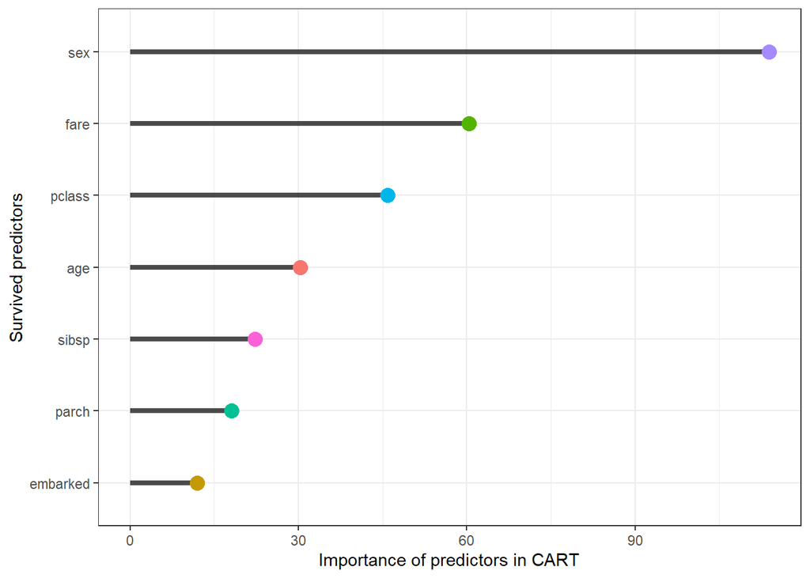

The next plot outlines the classification tree. Each split node contains a column name. On the left and right sides there are one or more levels of this column. They define the binary split which is the classification rule on current hierarchy. The colored nodes at the bottom of the tree represent the final outcome of the classification. For example, the splits for the last right node are following:

the prediction is the survived = 1 with probability 0.93. There are 23% of all records described by this node and satisfying conditions of these splits.

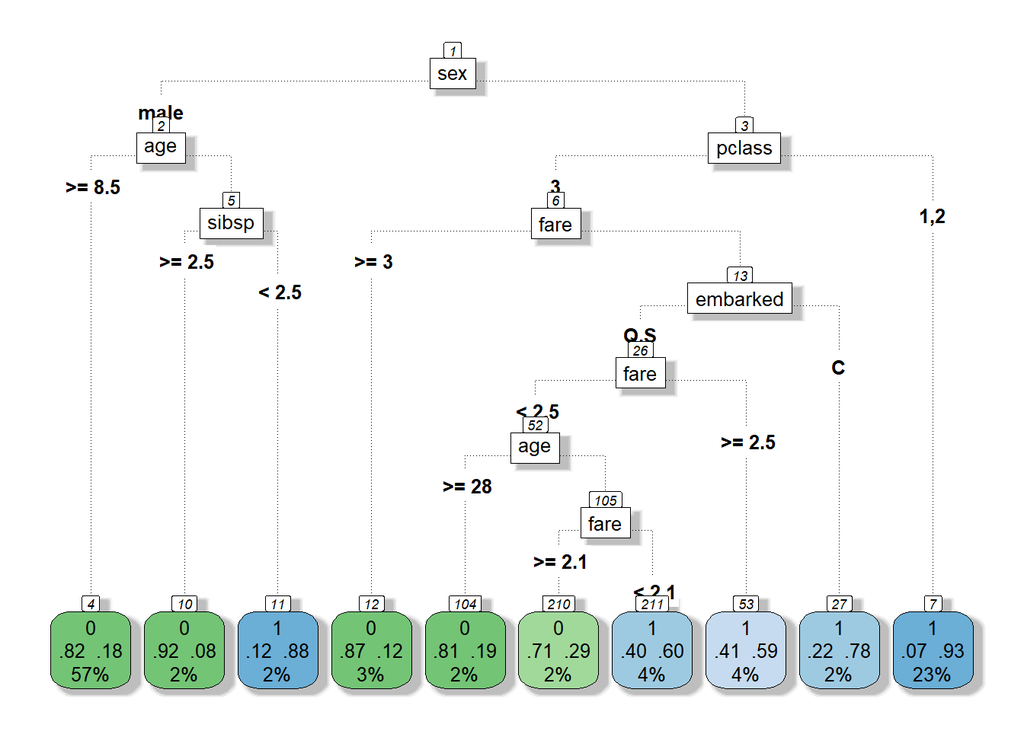

### Random forest

The correct prediction obtained from this method is 0.81. Another evaluation of performance of the random forest predictor was obtained using a receiver operating characteristic curve (ROC). It outlines true positive and false positive rates. The point (0, 1) corresponds to the best possible prediction of true positives and an absence of false positives. The area under the corresponding curve will be equal to one. A real curve will be below an ideal curve, and an area below it describes a quality of the prediction.

The next plot shows the ROC curve for the random forest predictor. The area under curve is 0.86

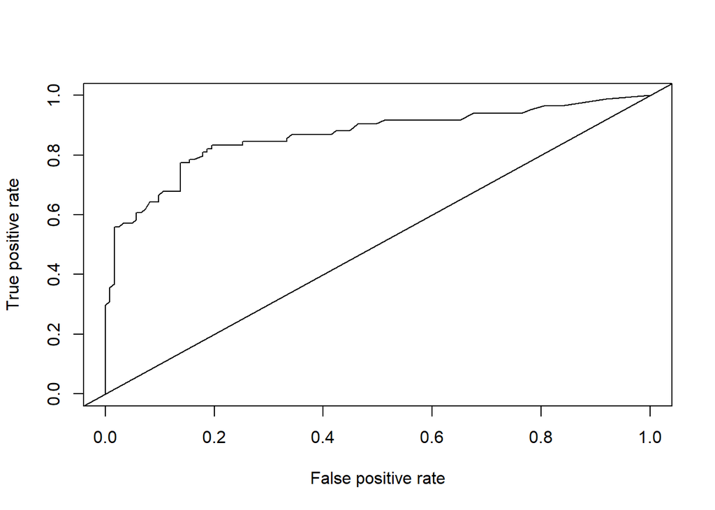

### Conclusions and further work

All 3 classification methods (logistic regression, CART, random forest) show over 80% of correct prediction rate. The next report will include the following additions:

1. Applying another methods, such as adaboost.
2. Analysis of another model without the age predictor and with more observations.
3. Possible imputation of missing records for improving the predictors.
4. Sensitivity analysis. Results of all classification methods depend on random split of the dataset onto training and testing sets. I will rerun all methods for various splits and check how they impact on correct prediction rate.

Also, I will add description of all methods and provide more generic code.